# Reimbursement Exploratory Data Analysis

This is a exploratory data analysis for global reimbursement amount.

- The date used is "Sent for Payment Date"
- Jun 2017 and July 2017 has been dropped in this dataset as that time we are under initial implementation status

**Target:**

1. To generate a complete picture of global reimbursement spending over time
2. To prepare for modeling cash forecast
3. To help day-to-day management and decision making

**Benefit:**

1. Generate cash forecast model to help prediction
2. Get insights and intuitions into global reimbursement spendings

```python
import pandas as pd
import matplotlib.pyplot as plt
import matplotlib
import seaborn as sns
import time
from datetime import datetime

import warnings
warnings.filterwarnings('ignore')

def fxn():
    warnings.warn("deprecated", DeprecationWarning)

with warnings.catch_warnings():
    warnings.simplefilter("ignore")
    fxn()

%matplotlib inline
sns.set(font_scale = 1.2)

#plotly.offline doesn't push your charts to the clouds
import plotly.offline as pyo
#allows us to create the Data and Figure objects
from plotly.graph_objs import *
import plotly.graph_objs as go
#plotly.plotly pushes your charts to the cloud
import plotly.plotly as py

#lets us see the charts in an iPython Notebook
pyo.offline.init_notebook_mode() # run at the start of every ipython
```

```python
from IPython.display import HTML

HTML('''<script>
code_show=true;
function code_toggle() {
 if (code_show){
 $('div.input').hide();
 } else {
 $('div.input').show();
 }
 code_show = !code_show
}
$( document ).ready(code_toggle);
</script>
<form action="javascript:code_toggle()"><input type="submit" value="Click here to toggle on/off the raw code."></form>''')
```

```python
# read and transfer date
df = pd.read_excel('sfpd_expenseType - Copy.xlsx',header=1)
df.drop(df.tail(1).index,inplace=True)

df['Year'] = df['Sent for Payment Date'].apply(lambda x: x.split('-')[0])
df['Month'] = df['Sent for Payment Date'].apply(lambda x: x.split('-')[1])

def func(x):
    return datetime.strptime(x, "%Y/%m/%d")
df['date']  = (df['Year'] + '/' + df['Month'] + '/1').apply(func)

# out of pocket dataframe
oop = df[df['Payment Type'] == 'Out-of-Pocket']
```

## Total Reimbursement Spending

### Trend

- There is a clear trend that the amount reimbursed is increasing month by month.
- There is a clear cycle pattern showed in the graph that we can use for estimating.
- It seems that the largest amount is at year end, following that is a significant drop which maybe due to Christmas event.

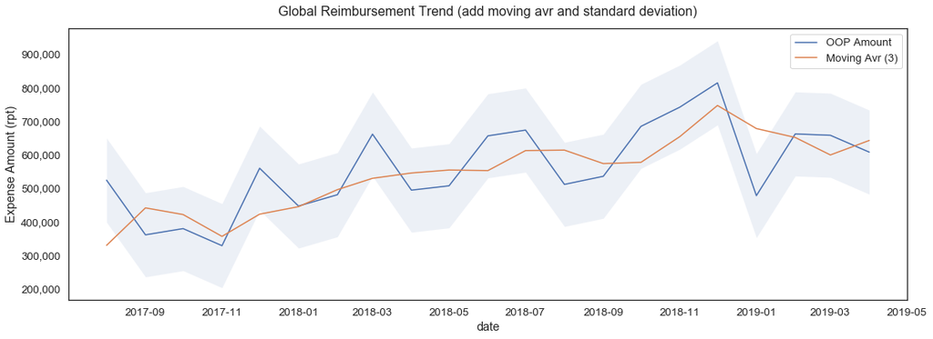

```python
# preparing data
total_df = oop.pivot_table('Expense Amount (rpt)','date',aggfunc=sum)
total_df.drop(total_df.index[0:2],inplace=True)
total_rolling = oop.pivot_table('Expense Amount (rpt)','date',aggfunc=sum).rolling(3).mean()
std = total_df.values.std()

# plot
sns.set_style('white')
plt.subplots(figsize=(18,6))

g = sns.lineplot(total_df.index,total_df['Expense Amount (rpt)'],label='OOP Amount')
g1= sns.lineplot(total_rolling.index,total_rolling['Expense Amount (rpt)'],label='Moving Avr (3)')

plt.fill_between(total_df.index,
                 total_df['Expense Amount (rpt)'] - std,
                 total_df['Expense Amount (rpt)'] + std,
                 alpha=0.1,label='Std')
# format
g.set_title('Global Reimbursement Trend (add moving avr and standard deviation)',fontdict={'fontsize':16},pad=15)

g.get_yaxis().set_major_formatter(
matplotlib.ticker.FuncFormatter(lambda x, p: format(int(x), ',')))

plt.show()
```

### Difference

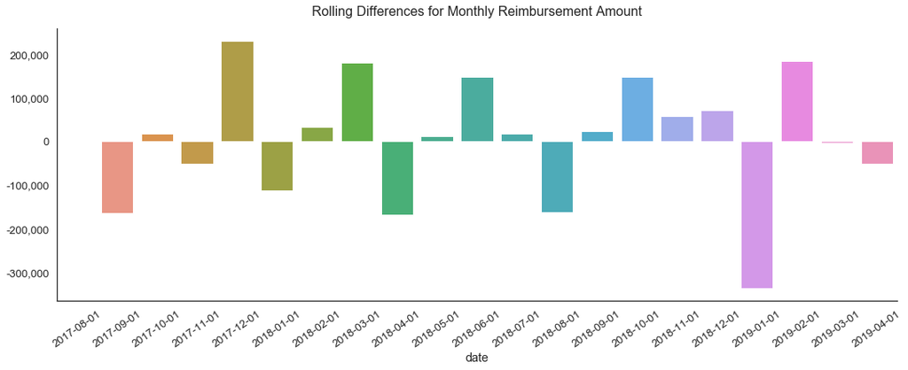

```
Mean fluctuation each month: $108,872.02
Standard deviation: $142,719.84
```

```python
# plot
plt.subplots(figsize=(18,6))

g = sns.barplot(total_df.reset_index()['date'].dt.date,total_df.diff()['Expense Amount (rpt)'].values)

g.set_title('Rolling Differences for Monthly Reimbursement Amount',fontdict={'fontsize':16},pad=15)
plt.setp(g.get_xticklabels(), rotation=35)

g.get_yaxis().set_major_formatter(
matplotlib.ticker.FuncFormatter(lambda x, p: format(int(x), ',')))

sns.despine()
plt.show()
# print out some information
print('Mean fluctuation each month: ${:,.2f}'.format(total_df.diff().apply(abs).mean()[0]))
print('Standard deviation: ${:,.2f}'.format(total_df.diff().std()[0]))
```

### Statistic Data

From the historical data, we can know:

**Distribution of Total Reimbursement Amount Each Month**

```
count         21
mean     559,929
std      128,652
min      328,200
5%       360,565
25%      480,256
50%      535,286
75%      661,012
95%      741,603
max      814,021
dtype: object
```

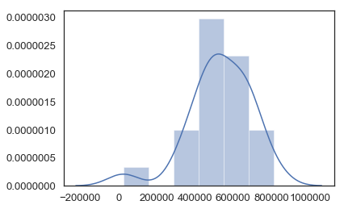

```python
total_oop = oop.pivot_table('Expense Amount (rpt)','date',aggfunc=sum)
total_oop.drop(total_oop.index[0:2],inplace=True)

sns.distplot(oop.pivot_table('Expense Amount (rpt)','date',aggfunc=sum))

print(total_oop.describe(percentiles=[.05,.25,.5,.75,.95]).apply(lambda x: '{:,.0f}'.format(x.values[0]),axis=1))
```

## Parent Expense Type

In this section, we break down total expense spending into different expense types. Firstly, let's see the amount of each expense type.

### Overall Amount

Not surprisingly, transportation and travel expenses (should these two types be together?) are the largest parts in employee reimbursement. Following is the Meal & Entertainment, which seems like 20% of the total. Communication (phone and internets) and HR benefit take another part. Surprisingly to see that marketing expenses only take like 2% or less.

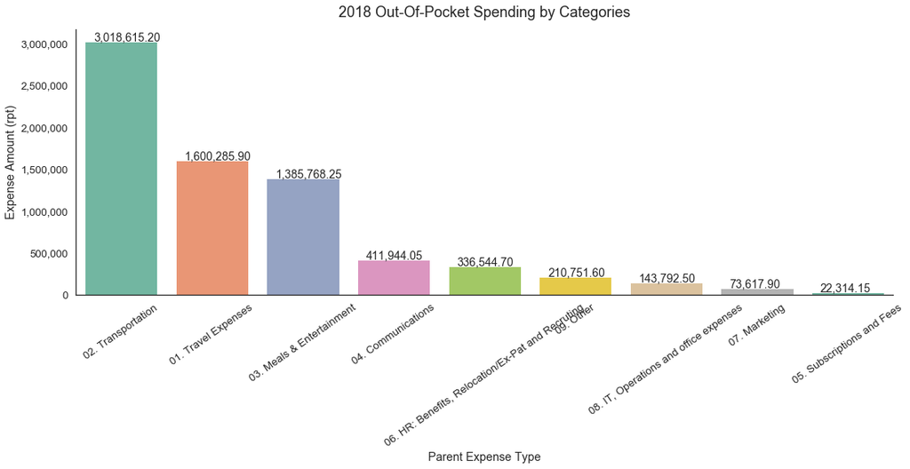

```python
# df
oop2018 = oop[oop['Sent for Payment Date'].apply(lambda x: '2018' in x)]

parent_et_df = (oop2018.pivot_table('Expense Amount (rpt)','Parent Expense Type', aggfunc=sum)
                .sort_values('Expense Amount (rpt)',ascending=False))

# plot
plt.subplots(figsize=(18,6))
g = sns.barplot(parent_et_df.index,parent_et_df['Expense Amount (rpt)'],palette='Set2')

# format
plt.setp(g.get_xticklabels(), rotation=35)
sns.despine()
g.set_title('2018 Out-Of-Pocket Spending by Categories',fontdict={'fontsize':18},pad=15)
g.get_yaxis().set_major_formatter(
matplotlib.ticker.FuncFormatter(lambda x, p: format(int(x), ',')))

# annotate
for ind, val in enumerate(parent_et_df.values):
    g.annotate('{:,.2f}'.format(val[0]),(ind-.3,val[0]+10000),size=14)
```

```python
parent_et_df
```

| Parent Expense Type | Expense Amount (rpt) |
| --- | --- |
| 02. Transportation | 3018615.20 |
| 01. Travel Expenses | 1600285.90 |
| 03. Meals & Entertainment | 1385768.25 |
| 04. Communications | 411944.05 |
| 06. HR: Benefits, Relocation/Ex-Pat and Recruting | 336544.70 |
| 09. Other | 210751.60 |
| 08. IT, Operations and office expenses | 143792.50 |
| 07. Marketing | 73617.90 |
| 05. Subscriptions and Fees | 22314.15 |

### Percentage of total

```python
tem_df = oop2018.pivot_table('Expense Amount (rpt)','Parent Expense Type','Sub', aggfunc=sum)
# total column
tem_df['Total'] = tem_df.apply(lambda x: x.sum(),axis=1)
# sort this column
tem_df.sort_values('Total',ascending=False,inplace=True)
# total row
tem_df.loc['Total',:] = tem_df.apply(lambda x: x.sum(),axis=0)
# sort this row
tem_df.sort_values('Total',axis=1,ascending=False,inplace=True)
# drop
tem_df.drop('Total',axis=0,inplace=True)
tem_df.drop('Total',axis=1,inplace=True)
# transform it into percentile
for col in tem_df.columns:
    total = tem_df[col].sum()
    tem_df[col] = tem_df[col].apply(lambda x: round(x/total,2))
```

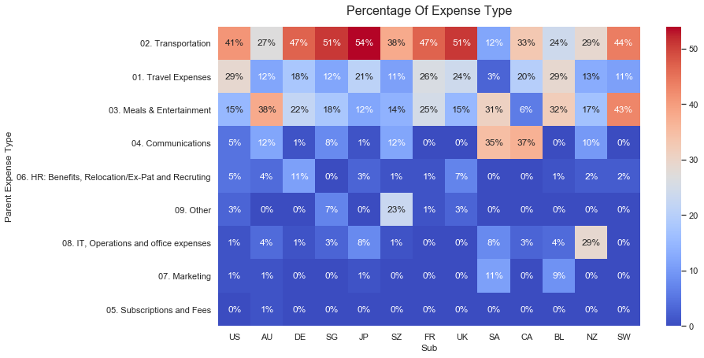

```python
# plot
sns.set(font_scale = 1)
plt.subplots(figsize=(12,7))

ax = sns.heatmap(tem_df.fillna(0)*100,cmap='coolwarm',annot=True)

ax.set_title('Percentage Of Expense Type',fontdict={'fontsize':16},pad=15)

for t in ax.texts: t.set_text(t.get_text() + "%")

plt.show()
```

### Changes over time

One of the most important thing to create a model and predict a future value is that, the data you are predicting needs to have either seasonal pattern or a predictable trend.

**Line Chart for Amount**

```python
oop['date'] = oop.date.dt.date
```

```python
test = oop.pivot_table('Expense Amount (rpt)','date','Parent Expense Type', aggfunc=sum)
for col in test.columns:
    test[col] = test[col].apply(lambda x: round(x,2))
```

```python
def visible(col):
    ls = ['01', '02', '03', '04']
    for i in ls:
        if i in col:
            return True
    return 'legendonly'

traces = []
for col in test.columns:
    traces.append({'type' : 'scatter',
                   'x' : test.index,
                   'y' : test[col],
                   'name' : col,
                   'mode' : 'lines',
                   'visible' : visible(col)})
data = Data(traces)


layout = {'title' : 'Interesting Trend in 2018',
         'xaxis' : {'title' : 'Month','tickformat':'%b %y'},
         'yaxis' : {'title' : 'Out-of-Pocket','tickformat':'$,0'}}

fig = Figure(traces, layout = layout)
pyo.iplot(fig)
```

[interactive chart not shown]

In the line chart above, we can see:

- An increasing trend for Travel, Transportation and Meal.
- Transportation and meal have a peak during Nov and Dec, this might be the reason why Nov and Dec have a high overall amount of spending. We need to dig deeper for these two kind of parent types to see what the peak consists of.

**Stacked bar chart and Line chart for percentage**

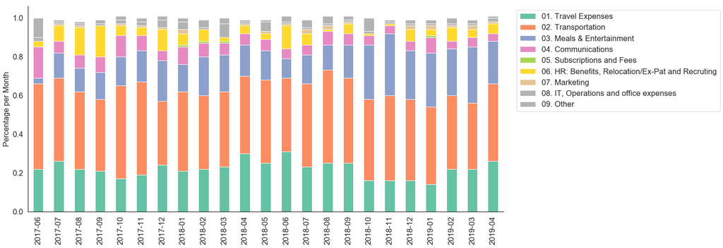

```python
# df
tem_df = oop.pivot_table('Expense Amount (rpt)','date','Parent Expense Type', aggfunc=sum).transpose()

for col in tem_df.columns:
    total = tem_df[col].sum()
    tem_df[col] = tem_df[col].apply(lambda x: round(x/total,2))


tem_df2 = tem_df.transpose()
tem_df2.index = [str(i)[:7] for i in tem_df2.index]

# plot
sns.set(font_scale = 1.5)
sns.set_style('white')
ax = tem_df2.plot(kind='bar',stacked=True,figsize=(18,8),legend=False,cmap='Set2')

# legend
patches, labels = ax.get_legend_handles_labels()
ax.legend(patches, labels, loc=5)
ax.legend(bbox_to_anchor=(1.02, 1.0))

# format
ax.set_ylabel('Percentage per Month',fontdict={'fontsize':16})
sns.despine()

plt.show()
```

```python
# trying to use plotly... but the cmap is not cool

# traces = []

# for col in tem_df2.columns:
#     traces.append({'type': 'bar',
#                    'x': tem_df2.index,
#                    'y': tem_df2[col],
#                    'opacity' : 0.7,
#                   'name':col})

# data = Data(traces)
# layout = {'title' : "Proportion of Parent Expense Types, Jun 2017 to April 2019",
#          'xaxis' : {'title' : 'Month', 'tickformat':'%b %y'},
#          'yaxis' : {'title' : 'Proportion of Month Total','tickformat': '.0%'},
#          'barmode' :'stack'}
# fig = Figure(data = data, layout = layout)
# pyo.iplot(fig)
```

We can see the most unstable category is Meal & Entertainment. The rest of them are all good.